# Méthode d’Évaluation des Coûts liés à l’Open Source (ECOS)

Version 1.0 - 21/11/2012

Ce document décrit la méthode ECOS, conçue pour évaluer les coûts liés à l’Open Source de manière objective, traçable et argumentée. Elle est mise à disposition de tous selon les termes de la GNU Free Documentation Licence.

# Note de licence

Copyright © 2012-2013 Atos.

Vous pouvez copier, redistribuer et/ou modifier ce document selon les termes de la Licence de Documentation Libre GNU, Version 1.2 publiée par la Free Software Foundation ; la Section Invariante étant « Manifeste ECOS », le Texte de Première de Couverture étant : « Ce document décrit la méthode ECOS, conçue pour évaluer les coûts liés à l’Open Source de manière objective, traçable et argumentée. Elle est mise à disposition de tous selon les termes de la GNU Free Documentation Licence. », et aucun Texte de Quatrième de Couverture.

Une copie de la licence en langue anglaise est consultable sur le site [`http://www.gnu.org/copyleft/fdl.html`](http://www.gnu.org/copyleft/fdl.html), une traduction française non officielle est consultable sur le site Web de Wikipedia ([`http://fr.wikipedia.org/wiki/FDL`](http://fr.wikipedia.org/wiki/FDL)).

# Historique des modifications

| Version | Date | Auteurs | Commentaires |
| --- | --- | --- | --- |
| 1.0 | 21/11/2012 | Thomas Moreau (Atos) Raphaël Semeteys (Atos) | Conception et rédaction initiales. |

# Introduction

## Objet du document

Ce document présente la méthode, baptisée « ECOS » (Évaluation des Coûts liés à l’Open Source), conçue par Atos pour évaluer les coûts liés à l’Open Source dans le cadre de ses travaux de conseil et de migration de logiciels. La méthode peut s'intégrer dans le cadre plus général d'un processus d’urbanisation du système d’information qui n'est pas présenté ici, et décrit un processus d'évaluation des coûts de possession de logiciels et de retour sur investissements.

## Public visé

Le présent document vise les publics suivants :

- les personnes curieuses de se documenter sur la méthode à titre professionnel comme personnel ;
- les communautés des projets libres et Open Source ;
- les experts du secteur informatique désirant connaître et appliquer la méthode dans leur travail quotidien d'évaluation et de sélection de composants dans l'optique de bâtir des solutions logicielles répondant à leurs besoins ou à ceux de leurs clients tout en minimisant les coûts ;
- les entreprises et organisations souhaitant évaluer les coûts liés à l’Open Source dans leur système d’information.

# Manifeste ECOS

## De la nécessité d’une méthode

Le coût des logiciels libres et Open Source fait l’objet de nombreuses idées reçues. En effet, le terme anglais « free » peut aussi bien signifier la « gratuité » que la « liberté ». Ainsi, une expression est née pour lever cette ambiguïté : « Think free as in free speech, not free beer ».

La réduction des coûts pousse souvent à considérer l’open source. Il faut cependant vérifier, dès les phases en amont, les éventuels bénéfices et les économies réalisées afin d’éviter les surprises. Tout projet de déploiement, même sans coûts de licences, reste un projet avec des coûts associés.

Il faut bien faire la distinction entre réduction et déplacement de coûts. Il est nécessaire d’intégrer la dimension financière dans toute réflexion sur l’open source.

Il est alors nécessaire de disposer d’une méthode d’évaluation des coûts liés au déploiement et à l’utilisation de logiciels libres et Open Source.

- Quel est le coût du support de ce logiciel par rapport au logiciel en place ?
- Quel est le coût du changement ?
- Quels sont les gains de productivité estimés?
- Quelles sont les économies d’acquisition et de gestion des licences réalisées?
- Quelles sont les économies en terme d’infrastructure matérielle ?
- Quel est le coût de la dépendance vis-à-vis d’un éditeur particulier ?

Pour pouvoir répondre sereinement à ce type d’interrogations et ainsi faire un choix éclairé en maîtrisant les risques, il est impératif de disposer d’une méthode offrant la possibilité :

- de comparer les coûts de possession des logiciels propriétaires vis-à-vis des logiciels libres et Open Source ;
- d’estimer les coûts du changement ;
- d’estimer le retour sur investissement.

Ce sont ces différents points qui ont poussé Atos à concevoir et formaliser la méthode d’Évaluation des Coûts liés à l’Open Source (ECOS).

## De la nécessité d’une méthode libre

Selon nous, une telle méthode se doit d'être mise à disposition de tous selon une licence libre. En effet, seule une telle licence est à même de garantir la promotion du mouvement libre et Open Source, via notamment :

- la possibilité de réutilisation par tous des travaux d'évaluation réalisés ;
- la qualité et l'objectivité des documents générés, toujours perfectibles selon les principes de transparence et de revue par les pairs.

À ce titre, Atos a décidé de placer la méthode ECOS sous la licence libre GNU Free Documentation Licence.

# Processus Général

La démarche d’évaluation de la méthode ECOS, composée de quatre étapes interdépendantes, commence en amont avant d’effectuer un choix, se poursuit pendant la mise en place ou la migration d’une partie du système d’information et continue après la transition terminée, en service régulier.

## Application continue

[figure not shown]

Application continue d'ECOS

La méthode ECOS peut être utilisée avant, pendant et après la mise en place d’une solution libre et open Source au sein du système d’information.

### Avant

La méthode ECOS peut être utilisée avant de prendre une décision. Elle permet de révéler les éléments importants permettant un choix avisé concernant l’adoption, la migration ou le rejet d’une solution libre et Open Source. La méthode permet d’identifier plusieurs cibles et plusieurs chemins de migration pertinents ainsi que de découvrir des opportunités intéressantes.

### Pendant

La méthode ECOS peut être utilisée pendant la mise en place d’une solution libre et Open Source. Elle permet de fournir des rapports financier, de suivre les écarts, d’affiner ou de réviser des hypothèses de départ et d’identifier des bifurcations économiques intéressantes.

### Après

La méthode ECOS peut être utilisée après la mise en place d’une solution libre et Open Source. Elle permet de valider des hypothèses, d’effectuer un bilan du projet et de communiquer les résultats.

## Étapes interdépendantes

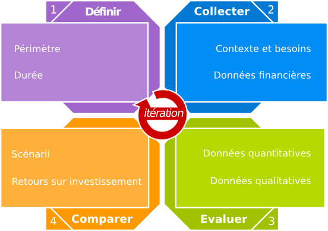

Processus général d'ECOS

La démarche générale d’ECOS se décompose en plusieurs étapes interdépendantes pouvant être appliquées avec des granularités différentes afin de s’adapter au niveau de détail souhaité :

[output not shown]

### Définir

#### Périmètre

La première étape du processus d’évaluation des coûts liés à l’Open Source consiste à définir le périmètre de l’étude. Il s’agit de choisir les domaines et secteurs du système d’information les plus à même de bénéficier d’une réduction de coûts substantielle, de part le coût particulièrement élevé des solutions existantes ou de part la difficulté à maintenir ou faire évoluer une solution basée sur un composant obsolète et fermé par exemple.

#### Durée

Le retour sur investissement est en général mesuré sur une période de 3 à 8 ans. Cette durée doit être fixée en accord avec le contexte et le plan stratégique de chaque organisation.

### Collecter

La seconde étape du processus d’évaluation des coûts liés à l’Open Source consiste à recueillir l’ensemble des données concernant l’usage (comme la criticité par exemple) et les coûts (licences, support...) des solutions des domaines ou secteurs du système d’information retenus dans l’étape précédente.

En plus des données chiffrées, il peut être nécessaire de s’entretenir avec les équipes en charge du système d’information afin de bien comprendre les besoins et les attentes.

### Évaluer

La troisième étape du processus d’évaluation des coûts liés à l’Open Source consiste à évaluer différentes solutions.

#### Deux modes d’évaluation

Les critères peuvent être évalués de deux manières :

- quantitativement, généralement en devise ou unité monétaire, pour mesurer l’efficacité économique, la profitabilité ;
- qualitativement, généralement une note de -1 à 1, car une méthode purement monétaire occulterait d’importants critères qualitatifs.

Les critères qualitatifs sont représentés sous forme de graphique. Afin d’avoir une bonne vision des coûts liés à l’Open Source, il est recommandé de n’évaluer que 5 critères de manière qualitative au maximum.

#### Les postes récurrents

##### Ressources matérielles

Des économies peuvent être réalisées en conservant du matériel ancien plutôt que de le renouveler, en réduisant la consommation d’énergie et en réduisant l’espace physique nécessaire en salle serveur.

**Exemple**

La société Orbitz, spécialiste en ligne du voyage, a choisi de remplacer une grande partie de son infrastructure de la base de donnée Oracle Coherence vers la base de données noSQL Couchbase. Ainsi, le nombre de serveurs nécessaires est passé de 400 à 70. La mémoire nécessaire est passée de 620Go à 55Go.

**Type de critère**

Le coût en ressources matérielles peut être mesuré financièrement sous réserve de disposer de données chiffrées fournies par les équipes en charge du système d’information. À défaut, une note de -1 à 1 peut être attribué à ce critère :

- 1 : les alternatives libres et Open Source consomment plus de ressources matérielles ;
- 0 : les alternatives libres et Open Source ont une consommation similaire ;
- -1 : les alternatives libres et Open Source ont une consommation moindre.

##### Sécurité

La sécurité est un élément essentiel de tout système d’information. Elle peut être mesurée financièrement ou qualitativement à travers le temps de découverte et de correction des failles.

**Exemple**

Pour l’Agence Nationale de la Sécurité des Systèmes d’Information (ANSSI) : « L'emploi de technologies propriétaires, maîtrisées par des intérêts extra-européens, est un handicap majeur pour la sécurité et la souveraineté nationale. La France, comme la plupart des autres pays européens, présente une forte vulnérabilité technologique dans ce domaine et seule l'utilisation des logiciels libres peut aujourd'hui encore constituer une parade possible. »

**Type de critère**

Le coût de la sécurité est difficilement mesurable. Les fournisseurs de solutions de sécurité annoncent des chiffres sans fournir la méthodologie ni les données utilisées pour l’évaluation. À moins que les équipes en charge du système d’information soient capables de fournir des données financières relatives à la sécurité, ce critère est évalué à l’aide d’une note de -1 à 1 :

- 1 : les alternatives libres et Open Source sont moins sûres ;
- 0 : les alternatives libres et Open Source ont une sûreté/sécurité similaire ;
- -1 : les alternatives libres et Open Source sont plus sûres.

##### Indépendance et interopérabilité

L’indépendance vis-à-vis d’un éditeur passe par l’utilisation de solutions interopérables.

**Exemple**

Le format Open Document est un standard ouvert et peut être utilisé par de nombreuses applications comme OpenOffice.org, LibreOffice, AbiWord, Google Drive, Koffice, MS Office 2007 et 2010, NeoOffice ou encore Sun Microsystems StarOffice. Le choix d’une solution peut imposer des choix en matière de système d’exploitation. Ainsi, la suite MS Office n’est pas disponible pour les plateformes Linux. Le choix d’un système d’exploitation peut imposer des choix en matière d’architecture matérielle. Ainsi, AIX est lié à l’architecture PowerPC, Solaris est lié à l’architecture SPARC et MS Windows est lié à l’architecture x86.

**Type de critère**

Le coût de la dépendance vis-à-vis d’un éditeur ou de l’interopérabilité est difficilement mesurable. À moins que les équipes en charge du système d’information soient capables de fournir des données financières relatives à la dépendance ou l’indépendance vis-à-vis d’un éditeur, ce critère est évalué à l’aide d’une note de -1 à 1 :

- 1 : les alternatives libres et Open Source renforcent la dépendance à un éditeur ;
- 0 : les alternatives libres et Open Source offrent une interopérabilité et une indépendance similaire ;
- -1 : les alternatives libres et Open Source offrent une meilleure interopérabilité et une plus grande indépendance ;

##### Productivité

La productivité peut grandement être améliorée par le choix d’une solution alternative.

**Exemple**

La conversion en PDF est une fonctionnalité native des suites OpenOffice et LibreOffice que l’on ne retrouve pas dans la suite Microsoft Office.

**Type de critère**

La productivité peut être mesurée financièrement sous réserve de disposer de données chiffrées fournies par les équipes en charge du système d’information. À défaut, une note de -1 à 1 peut être attribuée à ce critère :

- 1 : les alternatives libres et Open Source réduisent la productivité ;
- 0 : les alternatives libres et Open Source maintiennent la productivité ;
- -1 : les alternatives libres et Open Source augmentent la productivité.

##### Indisponibilité

Le choix de solutions alternatives peut permettre de réduire le temps d’indisponibilité des applications.

**Exemple**

Depuis la migration d’une grande partie de son infrastructure de la base de données Oracle Coherence vers la base de données noSQL Couchbase, la société Orbitz peut appliquer des changement sur ses applications web sans avoir besoin de les arrêter.

**Type de critère**

Le coût de l’indisponibilité est difficilement mesurable. À moins que les équipes en charge du système d’information soient capables de fournir des données financières relatives à l’indisponibilité, ce critère est évalué à l’aide d’une note de -1 à 1 :

- 1 : les alternatives libres et Open Source augmentent l’indisponibilité ;
- 0 : les alternatives libres et Open Source maintiennent l’indisponibilité ;
- -1 : les alternatives libres et Open Source réduisent l’indisponibilité.

##### Amélioration de l’image

La communication du passage à l’Open Source est l’occasion d’améliorer son image. Cela peut en effet être l’occasion de démontrer l’application réelle des valeurs de l’entreprise, comme l’expertise, la transparence, le travail collaboratif, l’esprit d’équipe ou le développement durable.

**Exemple**

Les sociétés Google et Twitter sont très reconnues pour leur participation au développement de solutions Open Source et jouissent d’une bonne image.

**Type de critère**

L’amélioration de l’image est mesurée qualitativement. Une note de -1 à 1 est attribuée à ce critère :

- 1 : les alternatives libres et Open Source dégradent l'imade du service, de l'entreprise ;
- 0 : les alternatives libres et Open Source maintiennent l'imade du service, de l'entreprise ;
- -1 : les alternatives libres et Open Source améliorent l'imade du service, de l'entreprise.

##### Support

De par sa nature ouverte, de nombreuses sociétés peuvent assurer le support d’une solution. Cette mise en compétition tire les prix vers le bas tout en maintenant une grande qualité de support.

**Exemple**

L’usage de logiciels libres dans un système d’information critique d’une direction ministérielle a permis de diviser par 10 les coûts de fonctionnement des applicatifs. Cette réduction nette des coûts a été obtenue en mettant en place un marché de maintenance dans des conditions très strictes (délais de 48h de résolution...) sur plus de 100 souches logicielles.

**Type de critère**

Le coût du support peut être mesuré financièrement sous réserve de disposer de données chiffrées fournies par les équipes en charge du système d’information. À défaut, une note de -1 à 1 peut être attribuée à ce critère :

- 1 : le support des alternatives libres et Open Source coûte plus cher ;
- 0 : le support des alternatives libres et Open Source a un coût similaire ;
- -1 : le support des alternatives libres et Open Source coûte moins cher.

##### Licences

Les solutions libres et Open Source permettent de faire des économies en acquisition et gestion de licences.

**Exemple**

Le coût des licences Oracle est connu pour être prohibitive tandis qu’il existe une alternative sans coût de licence associé : PostgreSQL.

**Type de critère**

Le coût de l’acquisition et de la gestion des licences peut être mesuré financièrement sous réserve de disposer de données chiffrées fournies par les équipes en charge du système d’information.

##### Innovation

L’utilisation de solutions Open Source peut permettre de créer de nouveaux bien et services et d’innover. En effet, l’accès aux sources permet de pouvoir entreprendre plus facilement des développements spécifiques.

**Exemple**

L’écosystème Hadoop et le mouvement noSQL sont les solutions Open Source leader du « big data ».

**Type de critère**

Le coût de l’innovation est difficilement mesurable. À moins que les équipes en charge du système d’information soient capables de fournir des données financières relatives à l’innovation, ce critère est évalué à l’aide d’une note de -1 à 1 :

- 1 : les alternatives libres et Open Source sont moins innovantes ou limitent l’innovation;
- 0 : les alternatives libres et Open Source innovent ou permettent l’innovation de manière similaire ;
- -1 : les alternatives libres et Open Source sont plus innovantes ou accélèrent l’innovation.

##### Qualité de service

Une solution libre et Open Source peut apporter une meilleure qualité de service.

**Exemple**

La société Orbitz a significativement amélioré la latence de ses applications tout en éliminant les pannes hebdomadaires depuis la migration d’Oracle Coherence vers Couchbase.

**Type de critère**

Le coût de la qualité de service est difficilement mesurable. À moins que les équipes en charge du système d’information soient capables de fournir des données financières relatives à la qualité de service, ce critère est évalué à l’aide d’une note de -1 à 1 :

- 1 : les alternatives libres et Open Source réduisent la qualité de service ;
- 0 : les alternatives libres et Open Source maintiennent la qualité de service ;
- -1 : les alternatives libres et Open Source augmentent la qualité de service.

##### Pérennité

La pérennité d’une solution et des données est essentielle. Elle l’est d’autant plus lorsque le cadre réglementaire impose des délais de conservation.

**Exemple**

L’utilisation d’un standard ouvert offre de bien meilleures garanties quant à la ré-utilisabilité des données de nombreuses années après.

**Type de critère**

Le coût de la pérennité est difficilement mesurable. À moins que les équipes en charge du système d’information soient capables de fournir des données financières relatives à la pérennité, ce critère est évalué à l’aide d’une note de -1 à 1 :

- 1 : les alternatives libres et Open Source sont moins pérennes ;
- 0 : les alternatives libres et Open Source sont aussi pérennes ;
- -1 : les alternatives libres et Open Source sont plus pérennes.

#### Les postes d’investissement

##### Nécessité ou urgence du changement

Le passage à l’Open Source peut résulter d’une attitude volontariste ou opportuniste. La nécessité du changement peut apparaître sous la contrainte juridique ou réglementaire, ou bien lors de l’obsolescence de la solution en place, en fin de vie (End Of Life) ou en fin de support (End Of Support). Il peut également être urgent de changer en raison de problèmes liés à la stabilité ou à la flexibilité de la solution en place.

**Exemple**

Les importants changement apportés par la version 2007 de la suite Microsoft Office ont été l’occasion de migrer vers la suite OpenOffice.org.

**Type de critère**

La nécessité du changement est mesurée qualitativement. Une note de -1 à 1 est attribuée à ce critère :

- 1 : le changement n’est pas nécessaire ou pas urgent ;
- 0 : le changement est nécessaire mais peu urgent ;
- -1 : le projet est nécessaire et urgent.

##### Formation

Le changement de logiciel peut nécessiter une formation du personnel.

**Exemple**

Formation au système de gestion de bases de données PostgreSQL.

**Type de critère**

Le coût de la formation du personnel est mesurée financièrement.

##### Communication

Une bonne communication est la clé de voûte de tout projet.

**Exemple**

Affiches, posters, brochures.

**Type de critère**

Les coûts de communication sont mesurés financièrement.

##### Valorisation

Un travail de valorisation des connaissances, à travers un wiki ou un forum par exemple, aide grandement à la transition vers la nouvelle solution choisie.

**Exemple**

Maintient d’un wiki ou d’un forum.

**Type de critère**

Les coûts de valorisation sont mesurés financièrement.

##### Surcharge de travail

Une surcharge de travail est a prévoir lors de la phase de transition entre les deux solutions.

**Exemple**

Maintenance des deux solutions en parallèle.

**Type de critère**

La surcharge de travail est évaluée financièrement.

##### Expertise

Le changement peut nécessiter l’intervention d’experts.

**Exemple**

Intervention d’un expert PostgreSQL pour la migration des données.

**Type de critère**

Le coût de l’expertise est évalué financièrement.

##### Ressources matérielles

L’ajout de ressources matérielles supplémentaires peut être nécessaire lors de la phase de transition entre les deux solutions.

**Exemple**

Location de serveurs.

**Type de critère**

Le coût de l’ajout de ressources matérielles supplémentaires est évalué financièrement.

##### Conversion de formats et développements spécifiques

Le passage d’une solution à une autre peut nécessiter la conversion de formats de données ou des développements spécifiques.

**Exemple**

Conversion de macros Microsoft Excel vers les macros Apache OpenOffice.

**Type de critère**

Le coût de conversion de formats et de développements spécifiques est évalué financièrement.

##### Tests et validation

Afin de s’assurer du bon fonctionnement de la solution, il est nécessaire de passer par des phases de tests et de validation.

**Exemple**

Réalisation d’une démonstration de faisabilité (POC)

**Type de critère**

Le coût des phases de tests et de validation est estimé financièrement.

### Comparer

La quatrième étape du processus d’évaluation des coûts liés à l’Open Source consiste à comparer de manière quantitative, qualitative et combinée (à l’aide de la note ECOS) les différents scenarii pertinents avec leur avantages, leurs inconvénients, leurs coûts, leurs bénéfices et leurs retours sur investissement.

# Outillage